> 07 Oct 2017 » seaborn, visualization

# Visualization with Python - seaborn

## seaborn

- Seaborn은 matplotlib을 기반으로 다양한 색상 테마와 통계용 챠트 등의 기능을 추가한 시각화 패키지이다.
- matplotlib 패키지에 의존한다.
- 통계 기능의 경우에는 statsmodels 패키지에 의존한다.
- documents
  - http://stanford.edu/~mwaskom/software/seaborn/index.html

### Style

- seaborn을 import하면 matplotlib에서 제공하는 기본 스타일이 아닌 **Seaborn에서 지정한 디폴트 스타일 집합으로 변경한다.**
- 따라서 동일한 matplotlib 명령을 수행해도 Seaborn을 임포트 한 것과 하지 않은 플롯은 모양이 다르다.

#### `set`은 스타일을, `set_color_codes`는 기본 색상을 변경한다.

```python
import seaborn as sns
sns.set()
sns.set_color_codes()
```

### 1차원 데이터 plot

- 실수 값 → 히스토그램 등의 plot
- 카테고리 값 → count plot

연습 데이터 load

```python
iris = sns.load_dataset("iris")
titanic = sns.load_dataset("titanic")
tips = sns.load_dataset("tips")
flights = sns.load_dataset("flights")
```

### 실수 분포 Plot

- 자료의 분포를 묘사하기 위한 것으로 matplotlib의 단순한 히스토그램과 달리 kernel density 및 rug표시 기능 및 다차원 복합 분포 기능 등을 제공한다.
- 실수 분포 플롯 명령에는 다음과 같은 것들이 있다.
  - `rugplot`
  - `kdeplot`
  - `distplot`
  - `jointplot`
  - `pairplot`

### rugplot

- 데이터 위치를 x축 위에 작은 선분으로 나타내어 실제 데이터 분포를 보여준다.

```python
import matplotlib as mpl
import matplotlib.pylab as plt
import numpy as np
%matplotlib inline
```

```python
np.random.seed(0)
x = np.random.randn(100)
```

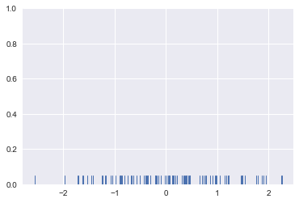

```python
sns.rugplot(x)
plt.show()
```

### kdeplot

- 커널 밀도(kernel density)는 커널이라고 하는 단위 플롯을 겹치는 방법이다.
- 히스토그램보다 부드러운 형태의 분포 곡선을 보여준다.
- 커널 밀도 추정에 대한 자세한 내용은 다음 scikit-learn 패키지를 참조하자.
  - http://scikit-learn.org/stable/modules/density.html

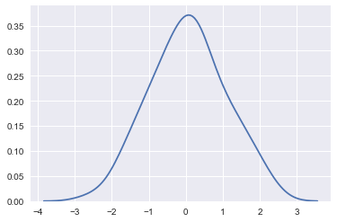

```python
sns.kdeplot(x)
plt.show()
```

### distplot

- seaborn의 `distplot`은 matplotlib의 히스토그램 명령을 대체하여 많이 쓰인다.
- 러그와 커널 밀도 표시 기능도 가지고 있다.

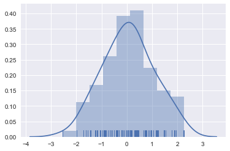

```python
sns.distplot(x, kde=True, rug=True)
plt.show()
```

#### distplot with subplot

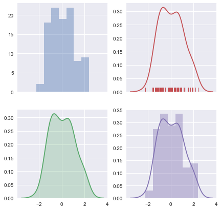

```python
d = np.random.normal(size=100)
f, axes = plt.subplots(2, 2, figsize=(7, 7), sharex=True)

sns.distplot(d, kde=False, color="b", ax=axes[0, 0])
sns.distplot(d, hist=False, rug=True, color="r", ax=axes[0, 1])
# kde_kws={"shade": True} → 히스토그램의 모양에 더 근접하게 그린다.
sns.distplot(d, hist=False, color="g", kde_kws={"shade": True}, ax=axes[1, 0])
sns.distplot(d, color="m", ax=axes[1, 1])
plt.show()
```

### countplot

- `countplot` 으로 각 카테고리별 데이터 값을 셀 수 있다.

```python
titanic.head()
```

|  | survived | pclass | sex | age | sibsp | parch | fare | embarked | class | who | adult_male | deck | embark_town | alive | alone |
| --- | --- | --- | --- | --- | --- | --- | --- | --- | --- | --- | --- | --- | --- | --- | --- |
| 0 | 0 | 3 | male | 22.0 | 1 | 0 | 7.2500 | S | Third | man | True | NaN | Southampton | no | False |
| 1 | 1 | 1 | female | 38.0 | 1 | 0 | 71.2833 | C | First | woman | False | C | Cherbourg | yes | False |
| 2 | 1 | 3 | female | 26.0 | 0 | 0 | 7.9250 | S | Third | woman | False | NaN | Southampton | yes | True |
| 3 | 1 | 1 | female | 35.0 | 1 | 0 | 53.1000 | S | First | woman | False | C | Southampton | yes | False |
| 4 | 0 | 3 | male | 35.0 | 0 | 0 | 8.0500 | S | Third | man | True | NaN | Southampton | no | True |

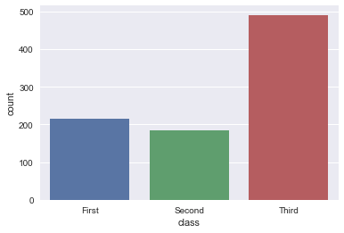

```python
sns.countplot(x="class", data=titanic)
plt.show()
```

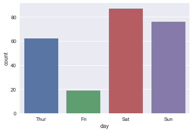

```python
sns.countplot(x="day", data=tips)
plt.show()
```

### 다차원 데이터

#### 데이터 변수가 여러 개인 다차원 데이터는 데이터의 종류에 따라 다음과 같은 경우가 있다.

- 분석하고자 하는 데이터가 **모두 실수 값인 경우**
- 분석하고자 하는 데이터가 **모두 카테고리 값인 경우**
- 분석하고자 하는 데이터가 **모두 실수 값과 카테고리 값이 섞여 있는 경우**

### 2차원 실수형 데이터 → jointplot

- 만약 데이터가 2차원이고 모두 연속적인 실수값이라면 스캐터 플롯(scatter plot)을 사용하면 된다.
- 스캐터 플롯을 그리기 위해서는 seaborn 패키지의 `jointplot` 명령을 사용한다.
- `jointplot` 명령은 스캐터 플롯뿐 아니라 각 변수의 히스토그램도 동시에 그린다.
- documents
  - http://seaborn.pydata.org/generated/seaborn.jointplot.html

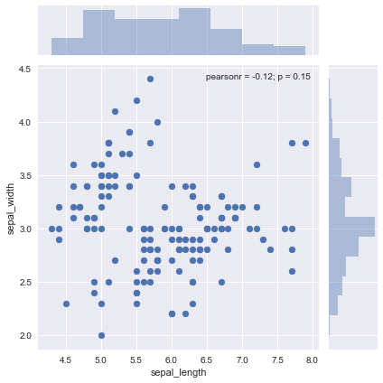

```python
sns.jointplot(x="sepal_length", y="sepal_width", data=iris)
plt.show()
```

### 또한 인수를 바꾸면 커널 밀도의 형태로도 표시할 수 있다.

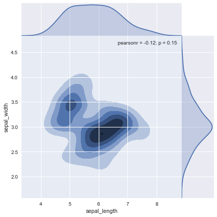

```python
sns.jointplot(x="sepal_length", y="sepal_width", data=iris, kind="kde", space=0, zorder=0, n_levels=6)
plt.show()
```

### 다차원 실수형 데이터 → pairplot

- 만약 3차원 이상의 데이터라면 seaborn 패키지의 `pairplot` 명령을 사용한다.
- `pairplot`은 그리도(grid) 형태로 각 집합의 조합에 대해 히스토그램과 스캐터 플롯을 그린다.
- documents
  - http://seaborn.pydata.org/generated/seaborn.pairplot.html

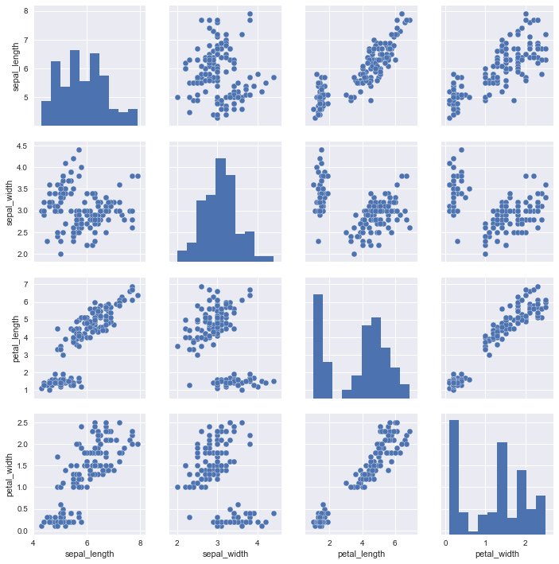

```python
sns.pairplot(iris)
plt.show()
```

### 만약 카테고리형 데이터가 실수형 데이터와 섞여 있다면 `hue` 인수를 이용하여 카테고리 별로 색상을 다르게 할 수 있다.

- 같은 카테고리인 경우 히스토그램으로 그린다.(대각선)

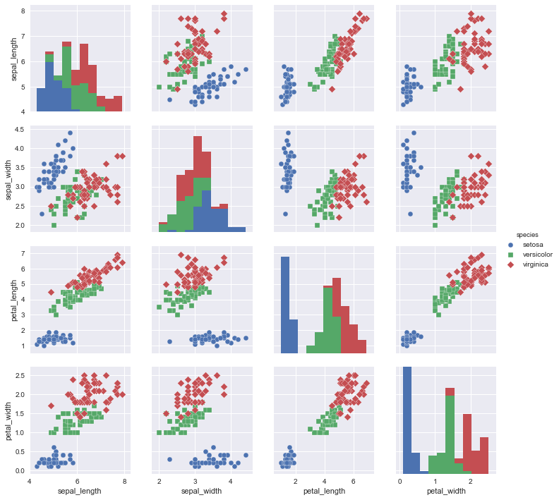

```python
# hue = "카테고리 컬럼명"
sns.pairplot(iris, hue="species", markers=["o", "s", "D"])
plt.show()
```

### 2차원 카테고리 데이터 → heatmap

- 만약 데이터가 2차원이고 모든 값이 카테고리 값이면 `heatmap` 명령을 사용한다.
- documents
  - http://seaborn.pydata.org/generated/seaborn.heatmap.html

```python
titanic.head()
```

|  | survived | pclass | sex | age | sibsp | parch | fare | embarked | class | who | adult_male | deck | embark_town | alive | alone |
| --- | --- | --- | --- | --- | --- | --- | --- | --- | --- | --- | --- | --- | --- | --- | --- |
| 0 | 0 | 3 | male | 22.0 | 1 | 0 | 7.2500 | S | Third | man | True | NaN | Southampton | no | False |
| 1 | 1 | 1 | female | 38.0 | 1 | 0 | 71.2833 | C | First | woman | False | C | Cherbourg | yes | False |
| 2 | 1 | 3 | female | 26.0 | 0 | 0 | 7.9250 | S | Third | woman | False | NaN | Southampton | yes | True |
| 3 | 1 | 1 | female | 35.0 | 1 | 0 | 53.1000 | S | First | woman | False | C | Southampton | yes | False |
| 4 | 0 | 3 | male | 35.0 | 0 | 0 | 8.0500 | S | Third | man | True | NaN | Southampton | no | True |

```python
# aggfunc="size" → pivot한 카테고리 값만 카운트
titanic_size = titanic.pivot_table(index="class", columns="embark_town", aggfunc="size")
titanic_size
```

| embark_town class | Cherbourg | Queenstown | Southampton |
| --- | --- | --- | --- |
| First | 85 | 2 | 127 |
| Second | 17 | 3 | 164 |
| Third | 66 | 72 | 353 |

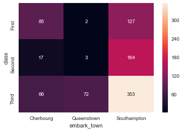

```python
sns.heatmap(titanic_size, annot=True, fmt="d")
plt.show()
```

### 2차원 복합 데이터

- 데이터가 2차원이고 실수 값, 카테고리 값이 섞여 있다면 기존의 플롯 이외에도 다음과 같은 분포 플롯들을 이용할 수 있다.
  - `barplot`
  - `boxplot`
  - `pointplot`
  - `violinplot`
  - `stripplot`
  - `swarmplot`

### `barplot`

- 카테고리 값에 따른 실수 값의 평균과 표준 편차를 표시하는 기본적인 바 차트를 생성한다.

```python
tips.head()
```

|  | total_bill | tip | sex | smoker | day | time | size |
| --- | --- | --- | --- | --- | --- | --- | --- |
| 0 | 16.99 | 1.01 | Female | No | Sun | Dinner | 2 |
| 1 | 10.34 | 1.66 | Male | No | Sun | Dinner | 3 |
| 2 | 21.01 | 3.50 | Male | No | Sun | Dinner | 3 |
| 3 | 23.68 | 3.31 | Male | No | Sun | Dinner | 2 |
| 4 | 24.59 | 3.61 | Female | No | Sun | Dinner | 4 |

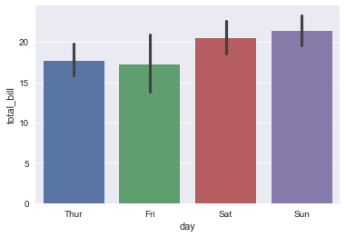

```python
sns.barplot(x="day", y="total_bill", data=tips)
plt.show()
```

### `boxplot`

- Box-Whisker Plot을 그려준다.
- Box는 실수 값 분포에서 1사분위수와 3사분위수를 뜻한다.
- 박스 내부의 가로선은 중앙값, 박스 외부의 세로선(Whisker)은 3사분위 수와 1사분위 수 사이의 거리의 1.5배 길이를 의미한다.
- 세로선 바깥의 점은 아웃라이어(outlier)이다.

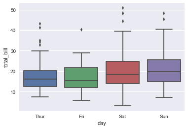

```python
sns.boxplot(x="day", y="total_bill", data=tips)
plt.show()
```

### 기타 Plot

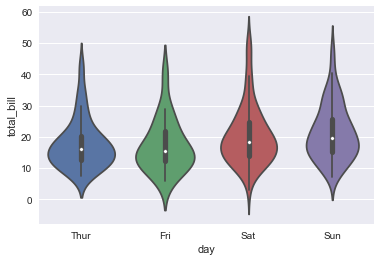

```python
sns.violinplot(x="day", y="total_bill", data=tips)
plt.show()
```

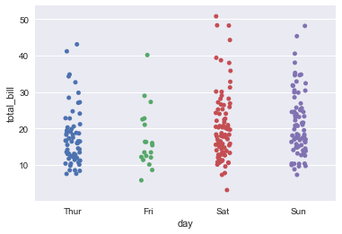

```python
sns.stripplot(x="day", y="total_bill", data=tips, jitter=True)
plt.show()
```

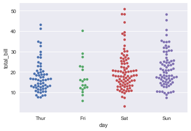

```python
sns.swarmplot(x="day", y="total_bill", data=tips)
plt.show()
```

### 다차원 복합 데이터

- 지금까지 소개한 대부분의 plot은 2차원 이상의 고차원 데이터에 대해서도 분석할 수 있는 기능이 포함되어 있다.
- 예를 들어 `barplot`, `violinplot`, `boxplot` 에서는 두 가지 카테고리 값에 의한 실수 값의 변화를 보기 위한 `hue` 인수를 제공한다.

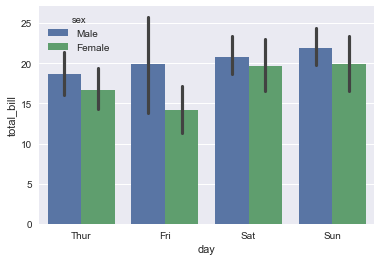

```python
tips = sns.load_dataset("tips")
sns.barplot(x="day", y="total_bill", hue="sex", data=tips)
plt.show()
```

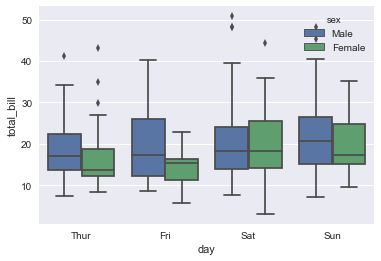

```python
sns.boxplot(x="day", y="total_bill", hue="sex", data=tips)
plt.show()
```

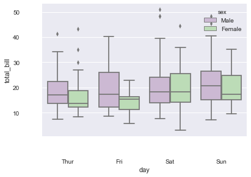

```python
tips = sns.load_dataset("tips")

# palette="PRGn" 처럼 색깔지정할 수 있다.
sns.boxplot(x="day", y="total_bill", hue="sex", data=tips, palette="PRGn")

# figure와 축 tick과의 거리 조정
sns.despine(offset=30, trim=True)
plt.show()
```

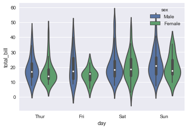

```python
sns.violinplot(x="day", y="total_bill", hue="sex", data=tips)
plt.show()
```

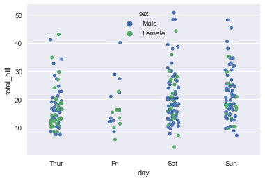

```python
sns.stripplot(x="day", y="total_bill", hue="sex", data=tips, jitter=True)
plt.show()
```

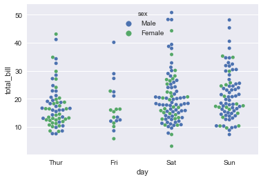

```python
sns.swarmplot(x="day", y="total_bill", hue="sex", data=tips)
plt.show()
```

### `stripplot`, `violinplot`, `swarmplot` 등 에서는 `split` 옵션으로 시각화 방법을 변경할 수도 있다.

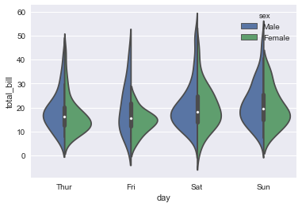

```python
sns.violinplot(x="day", y="total_bill", hue="sex", data=tips, split=True)
plt.show()
```

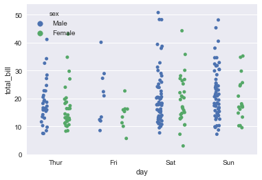

```python
sns.stripplot(x="day", y="total_bill", hue="sex", data=tips, jitter=True, split=True)
plt.show()
```

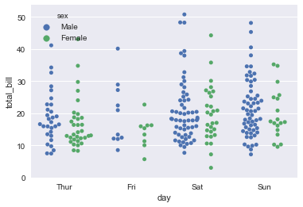

```python
sns.swarmplot(x="day", y="total_bill", hue="sex", data=tips, split=True)
plt.show()
```

### `heatmap`을 이용해도 두 개의 카테고리 값에 의한 실수 값 변화를 볼 수 있다.

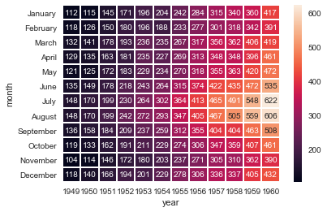

```python
flights_passengers = flights.pivot("month", "year", "passengers")
# annot=True 칸 안에 숫자를 채워라.
sns.heatmap(flights_passengers, annot=True, fmt="d", linewidths=1)
plt.show()
```

### `factorplot`

- 색상(hue)과 행(row) 등을 동시에 사용하여 **3개 이상의 카테고리 값에 의한 분포 변화를 보여준다.**

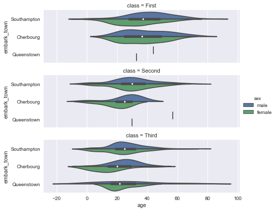

```python
sns.factorplot(x="age", y="embark_town", hue="sex", row="class", data=titanic[titanic.embark_town.notnull()],
               size=2, aspect=3.5, kind="violin", split=True)
plt.show()
```

### 여러 종류의 차트를 겹쳐서 표시

- 시각화 효과를 높이기 위해

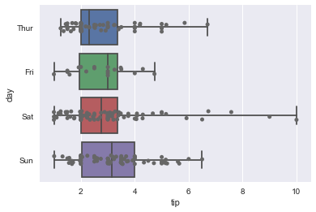

```python
sns.boxplot(x="tip", y="day", data=tips, whis=np.inf)
sns.stripplot(x="tip", y="day", data=tips, jitter=True, color="0.4")
plt.show()
```

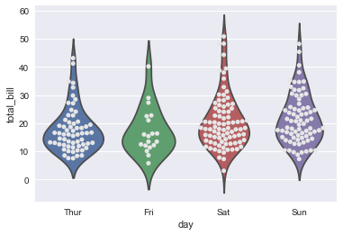

```python
sns.violinplot(x="day", y="total_bill", data=tips, inner=None)
sns.swarmplot(x="day", y="total_bill", data=tips, color="0.9")
plt.show()
```

### Aesthetic Parameters

- `set(context="notebook", style="darkgrid", palette="deep", font="sans-serif", font_scale=1, color_codes=False)`
  - `sns.set_context('notebook')`
    - notebook, paper, talk, poster
  - `sns.set_style('darkgrid')`
    - darkgrid, whitegrid, dark, white, ticks
  - `sns.set_palette('deep')`
    - deep, muted, pastel, bright, dark, colorblind

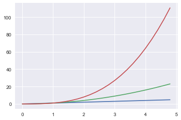

```python
t = np.arange(0., 5., 0.2)
sns.set_palette('deep')
plt.hold(True)
plt.plot(t, t)
plt.plot(t, t**2)
plt.plot(t, t**3)
plt.show()
```

## Bokeh

- http://bokeh.pydata.org/en/latest/
- interactive web rendering

```python
from bokeh.plotting import figure, output_notebook, show
x = [1, 2, 3, 4, 5]
y = [6, 7, 2, 4, 5]
output_notebook()
p = figure(title="simple line example", x_axis_label='x', y_axis_label='y')
p.line(x, y, legend="Temp.", line_width=2)
show(p)
```

[output not shown]

> Share this on → [Tweet](https://twitter.com/share)